# sensen

## This Analysis is based on data from Indonesian Fintech Startups company between August and October 2021.

The purpose from this analysis is to predict the likelihood of users to order the government bond and prepare how much bond that the company has to order.

```python
#import dependencies
import pandas as pd
import numpy as np
from matplotlib import pyplot as plt, dates as mdates
import seaborn as sns
#%matplotlib inline
```

```python
#function untuk convert dataset dari google drive / gdocs ke csv melalui panda
def convert(link, para):
    if para=='drive':
        potter = 'https://drive.google.com/uc?id='+ link.split('/')[-2]
    elif para =='docs':
        potter = link.replace('/edit#gid=', '/export?format=csv&gid=')
    return potter
```

```python
#convert dataset dari google drive panggil function yang sudah dibuat sebelumnya diatas
'''
data1 = pd.read_csv(convert('https://drive.google.com/file/d/11PIWh0ksBPsnC6Hm-idkid0nPUfMkeEf/view', 'drive'))
data2 = pd.read_csv(convert('https://drive.google.com/file/d/1uq_iZE0fWIp8qdDa-AC9OXx3BlgzTir3/view', 'drive'))
data3 = pd.read_csv(convert('https://docs.google.com/spreadsheets/d/1b6kWiu-LzMxwGdBagDaKWijRU2IkWGqF4HGjlJBCv2A/edit#gid=0', 'docs'))
'''

data1 = pd.read_csv(r'./data/user.csv')
data2 = pd.read_csv(r'./data/trans.csv')
data3 = pd.read_csv(r'./data/result.csv')
print(f'Total Row: {data1.shape[0]} , Column: {data1.shape[1]}')
#print the first 5 rows of data
data1.head()
```

```
Total Row: 14712 , Column: 8
```

|  | user_id | registration_import_datetime | user_gender | user_age | user_occupation | user_income_range | referral_code_used | user_income_source |
| --- | --- | --- | --- | --- | --- | --- | --- | --- |
| 0 | 162882 | 2021-09-17 14:10:44 | Female | 51 | Swasta | > Rp 500 Juta - 1 Miliar | NaN | Gaji |
| 1 | 3485491 | 2021-10-09 11:11:34 | Female | 55 | Others | > Rp 50 Juta - 100 Juta | NaN | Gaji |
| 2 | 1071649 | 2021-10-08 01:27:30 | Male | 50 | Swasta | Rp 10 Juta - 50 Juta | NaN | Gaji |
| 3 | 3816789 | 2021-08-12 07:19:32 | Female | 53 | IRT | > Rp 50 Juta - 100 Juta | NaN | Gaji |
| 4 | 3802293 | 2021-08-15 09:31:24 | Female | 47 | PNS | > Rp 500 Juta - 1 Miliar | used referral | Gaji |

The first dataset = 'data1' is contained 14712 rows of data and 8 features:

user_id = users identity

registration_import_datetime = the date of user registered

user_gender = gender of the user, 'Male' or 'Female'

user_age = age of the user

user_occupation = occupation of the user

user_income_range = range of income, contained '> Rp 500 Juta - 1 Miliar' '> Rp 50 Juta - 100 Juta' 'Rp 10 Juta - 50 Juta' '< 10 Juta' '> Rp 100 Juta - 500 Juta' '> Rp 1 Miliar'

referral_code_used = if the user using referral code during registration or not

user_income_source = the source of income from the user

Then we will be checking the data information to see if the dataset datatype is in the correct format or not.

```python
#check the dataset information
data1.info()
```

```
<class 'pandas.core.frame.DataFrame'>
RangeIndex: 14712 entries, 0 to 14711
Data columns (total 8 columns):
 #   Column                        Non-Null Count  Dtype
---  ------                        --------------  -----
 0   user_id                       14712 non-null  int64
 1   registration_import_datetime  14712 non-null  object
 2   user_gender                   14712 non-null  object
 3   user_age                      14712 non-null  int64
 4   user_occupation               14712 non-null  object
 5   user_income_range             14712 non-null  object
 6   referral_code_used            5604 non-null   object
 7   user_income_source            14712 non-null  object
dtypes: int64(2), object(6)
memory usage: 919.6+ KB
```

From the dataset information, we can see the datatype of registration_import_datetime is object. Meanwhile from the first 5 rows of data, it clearly show that the datatype is supposed to datetime. So we will convert the datatype from object to datetime.

```python
#convert to datetime
data1.registration_import_datetime = pd.to_datetime(data1['registration_import_datetime']).dt.to_period('d')

#double check
data1.info()
```

```
<class 'pandas.core.frame.DataFrame'>
RangeIndex: 14712 entries, 0 to 14711
Data columns (total 8 columns):
 #   Column                        Non-Null Count  Dtype
---  ------                        --------------  -----
 0   user_id                       14712 non-null  int64
 1   registration_import_datetime  14712 non-null  period[D]
 2   user_gender                   14712 non-null  object
 3   user_age                      14712 non-null  int64
 4   user_occupation               14712 non-null  object
 5   user_income_range             14712 non-null  object
 6   referral_code_used            5604 non-null   object
 7   user_income_source            14712 non-null  object
dtypes: int64(2), object(5), period[D](1)
memory usage: 919.6+ KB
```

```python
#double check
data1.head()
```

|  | user_id | registration_import_datetime | user_gender | user_age | user_occupation | user_income_range | referral_code_used | user_income_source |
| --- | --- | --- | --- | --- | --- | --- | --- | --- |
| 0 | 162882 | 2021-09-17 | Female | 51 | Swasta | > Rp 500 Juta - 1 Miliar | NaN | Gaji |
| 1 | 3485491 | 2021-10-09 | Female | 55 | Others | > Rp 50 Juta - 100 Juta | NaN | Gaji |
| 2 | 1071649 | 2021-10-08 | Male | 50 | Swasta | Rp 10 Juta - 50 Juta | NaN | Gaji |
| 3 | 3816789 | 2021-08-12 | Female | 53 | IRT | > Rp 50 Juta - 100 Juta | NaN | Gaji |
| 4 | 3802293 | 2021-08-15 | Female | 47 | PNS | > Rp 500 Juta - 1 Miliar | used referral | Gaji |

We will be checking if there is any duplicate user_id. Since we can the user_id is our primary key.

```python
#check if there is any duplicated user_id
is_duplicate_data1 = data1.user_id.duplicated().sum()
total_user = data1.user_id.count()
print(f'Total Duplicate User_ID : {is_duplicate_data1}')
print(f'Total User : {total_user}')
```

```
Total Duplicate User_ID : 0
Total User : 14712
```

From the total user 14712, we find none duplicate user_id. Then we will be checking if there is any null value from the dataset.

```python
#check for the null value
data1.isnull().sum()
```

```
user_id                            0
registration_import_datetime       0
user_gender                        0
user_age                           0
user_occupation                    0
user_income_range                  0
referral_code_used              9108
user_income_source                 0
dtype: int64
```

We can see that we have 9108 null value in referral_code_used column. We will be checking the unique values from the dataset before we decide how we will treat the null value.

```python
for x in data1:
  uniqueValues = data1[x].unique()
  n_values = len(uniqueValues)
  if n_values <=50:
    print(f'Column: {x} -- total unique value: ({n_values}) {uniqueValues}')
```

```
Column: user_gender -- total unique value: (2) ['Female' 'Male']
Column: user_occupation -- total unique value: (9) ['Swasta' 'Others' 'IRT' 'PNS' 'Pengusaha' 'Pensiunan' 'TNI/Polisi' 'Guru'
 'Pelajar']
Column: user_income_range -- total unique value: (6) ['> Rp 500 Juta - 1 Miliar' '> Rp 50 Juta - 100 Juta'
 'Rp 10 Juta - 50 Juta' '< 10 Juta' '> Rp 100 Juta - 500 Juta'
 '> Rp 1 Miliar']
Column: referral_code_used -- total unique value: (2) [nan 'used referral']
Column: user_income_source -- total unique value: (10) ['Gaji' 'Keuntungan Bisnis' 'Lainnya' 'Dari Orang Tua / Anak' 'Undian'
 'Tabungan' 'Warisan' 'Hasil Investasi' 'Dari Suami / istri'
 'Bunga Simpanan']
```

From the unique value details above, in the column referral_code_used only have 2 unique value which is used referral or nan. We will be replacing nan into None instead of deleting the null value.

```python
#converting nan to none
data1.referral_code_used.fillna('None', inplace = True)

#double check if the change is successful
data1.referral_code_used.unique()
```

```
array(['None', 'used referral'], dtype=object)
```

```python
#double check for the null value
data1.isnull().sum()
```

```
user_id                         0
registration_import_datetime    0
user_gender                     0
user_age                        0
user_occupation                 0
user_income_range               0
referral_code_used              0
user_income_source              0
dtype: int64
```

We want to see the growth of the user that registered with the company between August and October 2021. When is the lowest and the highest time.

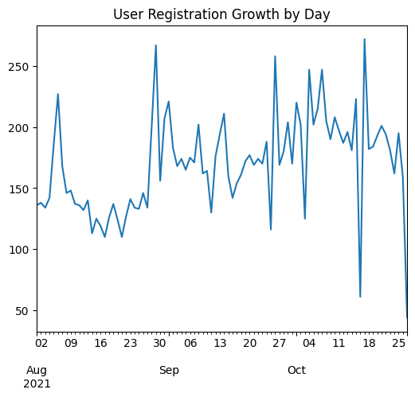

```python
#visualisasi perkembangan jumlah user yang bergabung dengan perusahaan
plt.subplots(figsize=(6, 5))
data1['registration_import_datetime'].value_counts().sort_index().plot()
plt.title('User Registration Growth by Day')
plt.show()
```

The line chart show that October is the month with lowest and highest registration. We will visualise another chart summarised by month of the registration to see which month is the highest.

The first thing we will do is to create a new column for registration by month for easier visualisation.

```python
#membuat column baru untuk registrasi berdasarkan bulan
data1['registration_month'] = data1.registration_import_datetime.dt.to_timestamp('m').copy()
data1.head()
```

|  | user_id | registration_import_datetime | user_gender | user_age | user_occupation | user_income_range | referral_code_used | user_income_source | registration_month |
| --- | --- | --- | --- | --- | --- | --- | --- | --- | --- |
| 0 | 162882 | 2021-09-17 | Female | 51 | Swasta | > Rp 500 Juta - 1 Miliar | None | Gaji | 2021-09-30 |
| 1 | 3485491 | 2021-10-09 | Female | 55 | Others | > Rp 50 Juta - 100 Juta | None | Gaji | 2021-10-31 |
| 2 | 1071649 | 2021-10-08 | Male | 50 | Swasta | Rp 10 Juta - 50 Juta | None | Gaji | 2021-10-31 |
| 3 | 3816789 | 2021-08-12 | Female | 53 | IRT | > Rp 50 Juta - 100 Juta | None | Gaji | 2021-08-31 |
| 4 | 3802293 | 2021-08-15 | Female | 47 | PNS | > Rp 500 Juta - 1 Miliar | used referral | Gaji | 2021-08-31 |

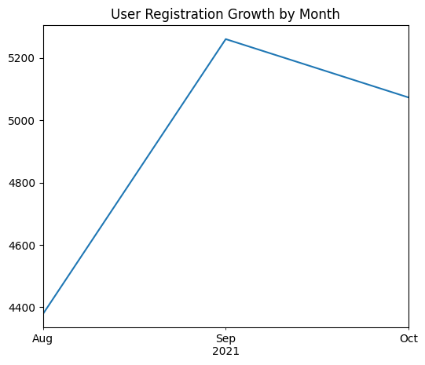

```python
#visualisasi perkembangan jumlah user yang bergabung dengan perusahaan berdasarkan bulan
plt.subplots(figsize=(6, 5))
data1.registration_month.value_counts().sort_index().plot()
plt.title('User Registration Growth by Month')
plt.show()
```

From the monthly registration line chart, we can see that September is the month with highest registration with more than 5200 users signed up. Then we want to check the distribution of users' gender

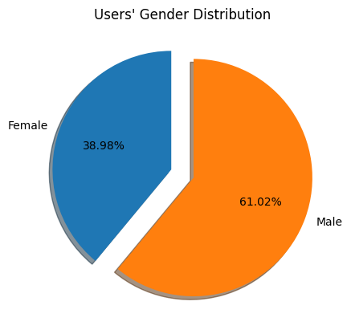

```python
gender = data1[['user_id', 'user_gender']].groupby('user_gender').count()
plt.pie(gender.user_id, labels=gender.index ,
        startangle=90, shadow=True,explode=(0.1, 0.1), autopct='%1.2f%%')
plt.title('Users\' Gender Distribution')
plt.show()
```

We can see from the pie chart that 61.02% of our users are male, meanwhile the rest are female. The next thing is we will explore the users' range and source of income.

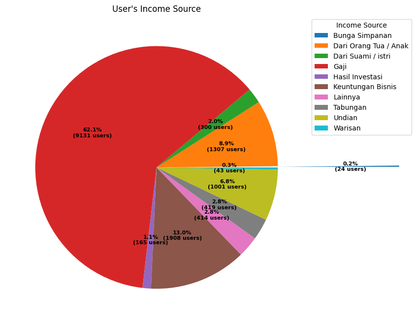

```python
fig, ax = plt.subplots(figsize=(8, 8), subplot_kw=dict(aspect="equal"))

income_source = data1[['user_id', 'user_income_source']].groupby('user_income_source').count()

def func(pct, allvals):
    absolute = int(np.round(pct/100.*np.sum(allvals)))
    return "{:.1f}%\n({:d} users)".format(pct, absolute)


wedges, texts, autotexts = ax.pie(income_source.user_id, autopct=lambda pct: func(pct, income_source.user_id),
                                  textprops=dict(color="black"), explode=(1,0,0,0,0,0,0,0,0,0))

ax.legend(wedges, income_source.index,
          title="Income Source",
          loc="upper left",
          bbox_to_anchor=(1, 0, 0.5, 1))

plt.setp(autotexts, size=8, weight="bold")

ax.set_title("User's Income Source")

plt.show()
```

We read the pie chart counterclockwise from the explode pie. The highest income source contribution from the users' are from 'Gaji'(Wages) and the lowest the income source is from interest with 0.2% or equal to 24 users.

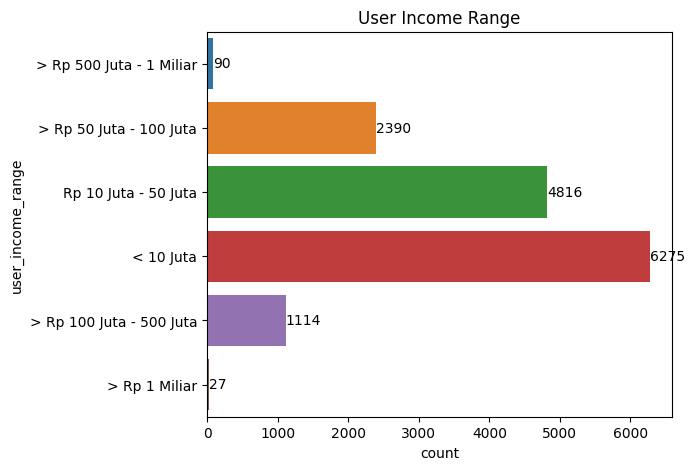

```python
#visualise income range
fig, ax = plt.subplots(figsize=(6, 5))
ax = sns.countplot(y= data1.user_income_range, data = data1)

ax.set_title('User Income Range')
for x in ax.containers:
        ax.bar_label(x, label_type='edge')

plt.show()
```

The bar chart above shows that most of our users' income range is less than 10 million Rupiah which is the lowest income range with 6275 users. Meanwhile there is 27 users with the highest income range, which can be our potential big investor.

Then we will break down with combination of income source and range.

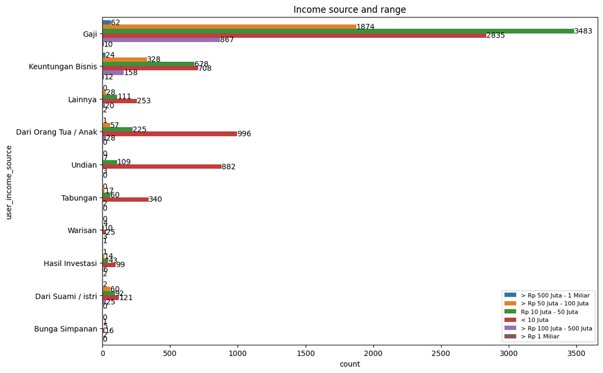

```python
#combine income source and range
fig, ax = plt.subplots(figsize=(12, 8))
ax = sns.countplot(y= data1.user_income_source, hue=data1.user_income_range, data = data1)

ax.set_title('Income source and range')
for x in ax.containers:
        ax.bar_label(x, label_type='edge')

ax.legend(loc='best', fontsize=8)
plt.show()
```

For the income range and source combination chart, we can see there are 2835 of our users had wages less than 10 Million Rupiah. Meanwhile the dominant range of wage is between 10 Million to 50 Million Rupiah. Then we will see the distribution of our users' occupation.

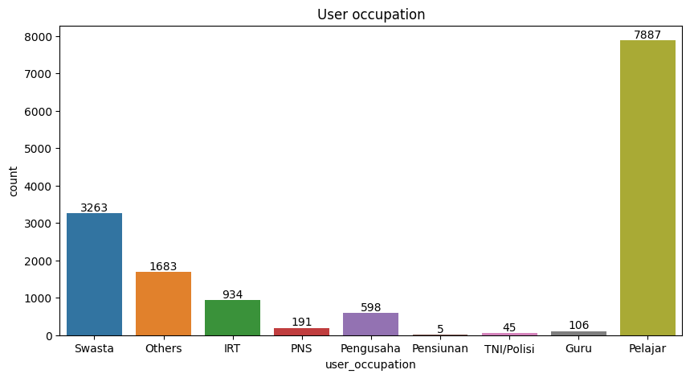

```python
fig, ax = plt.subplots(figsize=(10, 5))
ax =sns.countplot(x=data1.user_occupation)
for x in ax.containers:
        ax.bar_label(x, label_type='edge')
ax.set_title('User occupation')
plt.show()
```

The users' occupation chart shows that the majority of our users are student with total of 7887 user. Which is make sense that our majority income range is less than 10 Million.

We will try to combine the income range and user occupation to see more details of it.

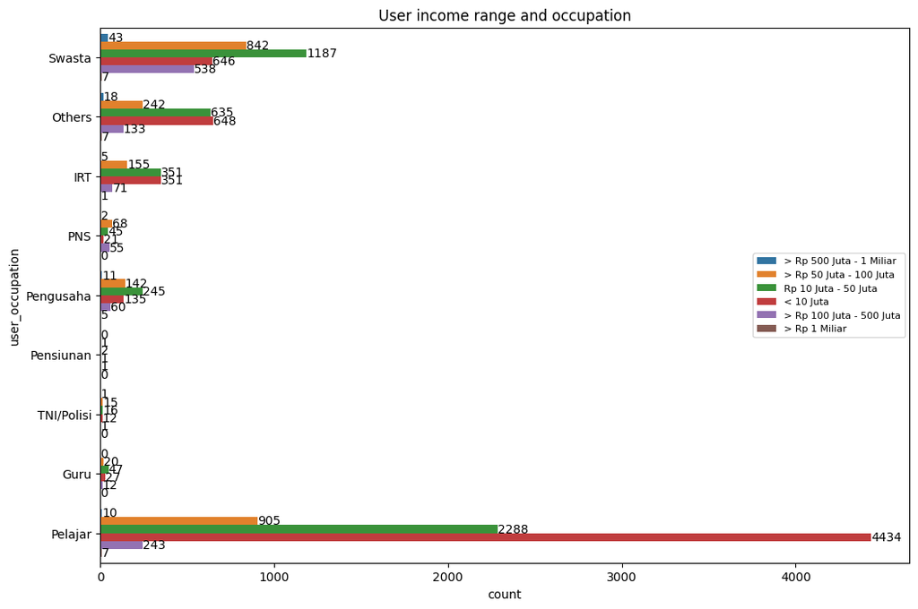

```python
#combine income source and range
fig, ax = plt.subplots(figsize=(12, 8))
ax = sns.countplot(y= data1.user_occupation, hue=data1.user_income_range, data = data1)

ax.set_title('User income range and occupation')
for x in ax.containers:
        ax.bar_label(x, label_type='edge')

ax.legend(loc='right', fontsize=8)
plt.show()
```

# grouping the customer age as a ranges and update to age coloumn

In the plot income range and occupation, we can see there are 17 students with income range more than 500 Million Rupiah which a little bit interesting for student has income that high. So we will check a little bit further for the 17 users.

```python
pelajar_age = data1.query('user_occupation == \'Pelajar\' and (user_income_range == \'> Rp 500 Juta - 1 Miliar\' or user_income_range == \'> Rp 1 Miliar\')')
pelajar_age
```

|  | user_id | registration_import_datetime | user_gender | user_age | user_occupation | user_income_range | referral_code_used | user_income_source | registration_month |
| --- | --- | --- | --- | --- | --- | --- | --- | --- | --- |
| 619 | 4228712 | 2021-10-05 | Male | 17 | Pelajar | > Rp 1 Miliar | used referral | Keuntungan Bisnis | 2021-10-31 |
| 899 | 3795261 | 2021-08-08 | Male | 18 | Pelajar | > Rp 1 Miliar | used referral | Lainnya | 2021-08-31 |
| 1394 | 4376258 | 2021-10-19 | Male | 18 | Pelajar | > Rp 500 Juta - 1 Miliar | used referral | Gaji | 2021-10-31 |
| 2282 | 3818578 | 2021-08-16 | Male | 19 | Pelajar | > Rp 1 Miliar | None | Keuntungan Bisnis | 2021-08-31 |
| 2609 | 3742646 | 2021-08-09 | Female | 20 | Pelajar | > Rp 1 Miliar | None | Keuntungan Bisnis | 2021-08-31 |
| 3999 | 3749935 | 2021-08-04 | Female | 21 | Pelajar | > Rp 1 Miliar | None | Keuntungan Bisnis | 2021-08-31 |
| 4076 | 4245492 | 2021-10-07 | Female | 21 | Pelajar | > Rp 500 Juta - 1 Miliar | None | Keuntungan Bisnis | 2021-10-31 |
| 4569 | 4355874 | 2021-10-17 | Male | 21 | Pelajar | > Rp 1 Miliar | used referral | Keuntungan Bisnis | 2021-10-31 |
| 6135 | 4239037 | 2021-10-06 | Female | 23 | Pelajar | > Rp 500 Juta - 1 Miliar | used referral | Gaji | 2021-10-31 |
| 8322 | 4371352 | 2021-10-19 | Male | 25 | Pelajar | > Rp 500 Juta - 1 Miliar | used referral | Gaji | 2021-10-31 |
| 8871 | 3959126 | 2021-09-02 | Female | 26 | Pelajar | > Rp 500 Juta - 1 Miliar | used referral | Keuntungan Bisnis | 2021-09-30 |
| 9063 | 4342801 | 2021-10-17 | Male | 26 | Pelajar | > Rp 500 Juta - 1 Miliar | None | Gaji | 2021-10-31 |
| 9725 | 4270298 | 2021-10-09 | Female | 27 | Pelajar | > Rp 500 Juta - 1 Miliar | None | Keuntungan Bisnis | 2021-10-31 |
| 10101 | 4134537 | 2021-09-24 | Male | 28 | Pelajar | > Rp 500 Juta - 1 Miliar | None | Keuntungan Bisnis | 2021-09-30 |
| 10925 | 4338825 | 2021-10-15 | Male | 29 | Pelajar | > Rp 1 Miliar | used referral | Lainnya | 2021-10-31 |
| 11617 | 4164878 | 2021-10-02 | Male | 31 | Pelajar | > Rp 500 Juta - 1 Miliar | used referral | Keuntungan Bisnis | 2021-10-31 |
| 11950 | 3858112 | 2021-08-18 | Female | 32 | Pelajar | > Rp 500 Juta - 1 Miliar | None | Gaji | 2021-08-31 |

From the list above, we can make assumption that it's possibile that some of the users came from a high income background family.

We will be plotting the comparison between users that used referral code and none.

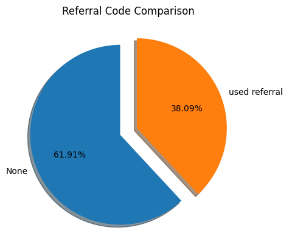

```python
referral_code = data1[['user_id', 'referral_code_used']].groupby('referral_code_used').count()
plt.pie(referral_code.user_id, labels=referral_code.index ,
        startangle=90, shadow=True,explode=(0.1, 0.1), autopct='%1.2f%%')
plt.title('Referral Code Comparison')
plt.show()
```

The visualisation above shows that only 38.09% from the user using referral code when they signed up. We could create a new marketing campaigne related to the referral code to increase the number of users that signed up.

The next thing we will do is check the average age of our users and see if there is any outliers or abnormal age input.

```python
data1['user_age'].describe()
```

```
count    14712.000000
mean        27.176591
std          8.552585
min         17.000000
25%         21.000000
50%         25.000000
75%         31.000000
max         83.000000
Name: user_age, dtype: float64
```

From the data description, we can see that the average age of our user is 27 years old. We will visualise the user_age using histogram for the distribution and boxplot.

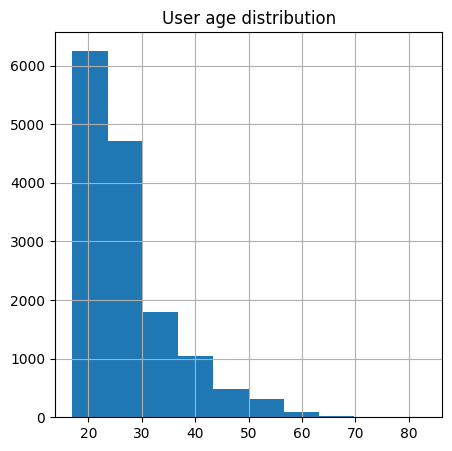

```python
data1['user_age'].hist(figsize = (5,5))
plt.title('User age distribution')
```

It shows that most of our users distribution are in the group of age 17 - 30ish.

We will be using zscore for outliers.

```
outliers in dataset are {53, 54, 55, 56, 57, 58, 59, 60, 61, 62, 63, 64, 65, 66, 67, 69, 71, 73, 74, 76, 82, 83}
```

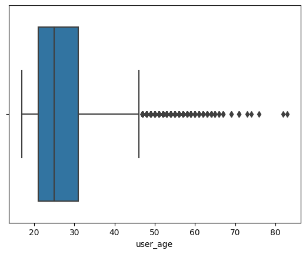

```python
#zscore outlier
mean = np.mean(data1.user_age)
std = np.std(data1.user_age)

outlier = []
for i in data1.user_age:
    z = (i-mean)/std
    if z > 3:
        outlier.append(i)
print('outliers in dataset are', set(outlier))
sns.boxplot(x=data1.user_age)
```

As we can see, we have outliers from users age 53 years and older. It make sense, since the average of our users is around 27 years old. We will be checking how many percentage of the user making transaction and how much is the contribution before we decide to remove the outliers or just leave it as is.

```
Total users in outliers : 264 OR 1.79% from total user
```

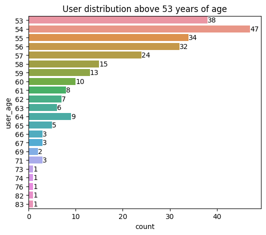

```python
user_outliers = data1.loc[data1.user_age>=53,:]
total_out = user_outliers.user_id.count()
percentage_outliers = (total_out/total_user)
print(f'Total users in outliers : {total_out} OR {percentage_outliers:.2%} from total user')

fig, ax = plt.subplots(figsize=(6, 5))
ax = sns.countplot(y= user_outliers.user_age, data = user_outliers)

ax.set_title('User distribution above 53 years of age')
for x in ax.containers:
        ax.bar_label(x, label_type='edge')

plt.show()
```

From the plot above, we can see that we have 264 outliers or equal to 1.79% from the total user. With the highest distribution on age 54 years old and the lowest start from 73 years old. We will be merging to the dataset 2 to see how much the 264 users contribute to the transactions.

Before that, we will do a quick exploration and clean the dataset 2.

## Explore dataset 2

```python
#print first 5 rows of dataset 2
print(f'Total rows: {data2.shape[0]} ,columns: {data2.shape[1]}')

transaction_users = data2['user_id'].nunique()
print(f'Total users making transaction period {data2.date.min()} - {data2.date.max()} = {transaction_users} users or {(transaction_users/total_user):.2%} from total users')
data2.head()
```

```
Total rows: 158811 ,columns: 14
Total users making transaction period 2021-08-04 - 2021-09-30 = 8277 users or 56.26% from total users
```

|  | user_id | date | Saham_AUM | Saham_invested_amount | Saham_transaction_amount | Pasar_Uang_AUM | Pasar_Uang_invested_amount | Pasar_Uang_transaction_amount | Pendapatan_Tetap_AUM | Pendapatan_Tetap_invested_amount | Pendapatan_Tetap_transaction_amount | Campuran_AUM | Campuran_invested_amount | Campuran_transaction_amount |
| --- | --- | --- | --- | --- | --- | --- | --- | --- | --- | --- | --- | --- | --- | --- |
| 0 | 50701 | 2021-08-30 | NaN | NaN | NaN | NaN | NaN | NaN | NaN | NaN | NaN | 10132277.0 | 10000000.0 | NaN |
| 1 | 50701 | 2021-08-31 | NaN | NaN | NaN | NaN | NaN | NaN | NaN | NaN | NaN | 10206945.0 | 10000000.0 | 0.0 |
| 2 | 50701 | 2021-09-01 | NaN | NaN | NaN | NaN | NaN | NaN | NaN | NaN | NaN | 9956556.0 | 10000000.0 | 0.0 |
| 3 | 50701 | 2021-09-02 | NaN | NaN | NaN | NaN | NaN | NaN | NaN | NaN | NaN | 9914858.0 | 10000000.0 | 0.0 |
| 4 | 50701 | 2021-09-03 | NaN | NaN | NaN | NaN | NaN | NaN | NaN | NaN | NaN | 10016360.0 | 10000000.0 | 0.0 |

On the dataset 2 (transactions), there are 158811 rows of data and 14 columns with details as below:

user_id = id of user, it's equal to user_id from dataset 1

date = transaction date

Saham_AUM = AUM of equity mutual fund held by client to date

Saham_invested_amount = The total price paid by client to buy equity mutual fund to date.

Saham_transaction_amount = Total value of transaction to buy (if positive) or sell (if negative) equity mutual fund on the date.

Pasar_Uang_AUM = AUM of money market mutual fund held by client to date

Pasar_Uang_invested_amount = The total price paid by client to buy money market mutual fund to date

Pasar_Uang_transaction_amount = Total value of transaction to buy (if positive) or sell (if negative) money market mutual fund on the date.

Pendapatan_Tetap_AUM = AUM of fixed income mutual fund held by client to date

Pendapatan_Tetap_invested_amount = The total price paid by client to buy fixed income mutual fund to date

Pendapatan_Tetap_transaction_amount = Total value of transaction to buy (if positive) or sell (if negative) fixed income mutual fund on the date.

Campuran_AUM = AUM of mixed mutual fund held by client to date

Campuran_invested_amount = The total price paid by client to buy mixed mutual fund to date

Campuran_transaction_amount = Total value of transaction to buy (if positive) or sell (if negative) mixed mutual fund on the date.

We will be checkin the dataset information and handling null value.

```python
#check datatype information
data2.info()
```

```
<class 'pandas.core.frame.DataFrame'>
RangeIndex: 158811 entries, 0 to 158810
Data columns (total 14 columns):
 #   Column                               Non-Null Count   Dtype
---  ------                               --------------   -----
 0   user_id                              158811 non-null  int64
 1   date                                 158811 non-null  object
 2   Saham_AUM                            106292 non-null  float64
 3   Saham_invested_amount                106292 non-null  float64
 4   Saham_transaction_amount             100839 non-null  float64
 5   Pasar_Uang_AUM                       131081 non-null  float64
 6   Pasar_Uang_invested_amount           131081 non-null  float64
 7   Pasar_Uang_transaction_amount        124273 non-null  float64
 8   Pendapatan_Tetap_AUM                 105946 non-null  float64
 9   Pendapatan_Tetap_invested_amount     105946 non-null  float64
 10  Pendapatan_Tetap_transaction_amount  100497 non-null  float64
 11  Campuran_AUM                         5352 non-null    float64
 12  Campuran_invested_amount             5352 non-null    float64
 13  Campuran_transaction_amount          5117 non-null    float64
dtypes: float64(12), int64(1), object(1)
memory usage: 17.0+ MB
```

From the dataset information, we can see the datatype for date is object. So, we will be converting the object to datetime, as well as changing the name into trans_date to avoid ambiguity with method.

```python
#rename column
data2.rename(columns={"date": "trans_date"}, inplace=True)
#convert to datetime
data2['trans_date'] = pd.to_datetime(data2['trans_date'])

#double check
data2.info()
```

```
<class 'pandas.core.frame.DataFrame'>
RangeIndex: 158811 entries, 0 to 158810
Data columns (total 14 columns):
 #   Column                               Non-Null Count   Dtype
---  ------                               --------------   -----
 0   user_id                              158811 non-null  int64
 1   trans_date                           158811 non-null  datetime64[ns]
 2   Saham_AUM                            106292 non-null  float64
 3   Saham_invested_amount                106292 non-null  float64
 4   Saham_transaction_amount             100839 non-null  float64
 5   Pasar_Uang_AUM                       131081 non-null  float64
 6   Pasar_Uang_invested_amount           131081 non-null  float64
 7   Pasar_Uang_transaction_amount        124273 non-null  float64
 8   Pendapatan_Tetap_AUM                 105946 non-null  float64
 9   Pendapatan_Tetap_invested_amount     105946 non-null  float64
 10  Pendapatan_Tetap_transaction_amount  100497 non-null  float64
 11  Campuran_AUM                         5352 non-null    float64
 12  Campuran_invested_amount             5352 non-null    float64
 13  Campuran_transaction_amount          5117 non-null    float64
dtypes: datetime64[ns](1), float64(12), int64(1)
memory usage: 17.0 MB
```

The next thing that we will do is checking for null value and replacing the null value

```python
#check null value
data2.isnull().sum()
```

```
user_id                                     0
trans_date                                  0
Saham_AUM                               52519
Saham_invested_amount                   52519
Saham_transaction_amount                57972
Pasar_Uang_AUM                          27730
Pasar_Uang_invested_amount              27730
Pasar_Uang_transaction_amount           34538
Pendapatan_Tetap_AUM                    52865
Pendapatan_Tetap_invested_amount        52865
Pendapatan_Tetap_transaction_amount     58314
Campuran_AUM                           153459
Campuran_invested_amount               153459
Campuran_transaction_amount            153694
dtype: int64
```

Most of the transaction column has null value if there is no input. So we will be replacing it to 0 instead of null.

```python
#because all of the features that consists null value has float datatype, we will be converting nan to 0 instead
data2.fillna(0, inplace=True)

#double check
data2.isnull().sum()
```

```
user_id                                0
trans_date                             0
Saham_AUM                              0
Saham_invested_amount                  0
Saham_transaction_amount               0
Pasar_Uang_AUM                         0
Pasar_Uang_invested_amount             0
Pasar_Uang_transaction_amount          0
Pendapatan_Tetap_AUM                   0
Pendapatan_Tetap_invested_amount       0
Pendapatan_Tetap_transaction_amount    0
Campuran_AUM                           0
Campuran_invested_amount               0
Campuran_transaction_amount            0
dtype: int64
```

```python
#print first 5 rows to double check
data2.head()
```

|  | user_id | trans_date | Saham_AUM | Saham_invested_amount | Saham_transaction_amount | Pasar_Uang_AUM | Pasar_Uang_invested_amount | Pasar_Uang_transaction_amount | Pendapatan_Tetap_AUM | Pendapatan_Tetap_invested_amount | Pendapatan_Tetap_transaction_amount | Campuran_AUM | Campuran_invested_amount | Campuran_transaction_amount |
| --- | --- | --- | --- | --- | --- | --- | --- | --- | --- | --- | --- | --- | --- | --- |
| 0 | 50701 | 2021-08-30 | 0.0 | 0.0 | 0.0 | 0.0 | 0.0 | 0.0 | 0.0 | 0.0 | 0.0 | 10132277.0 | 10000000.0 | 0.0 |
| 1 | 50701 | 2021-08-31 | 0.0 | 0.0 | 0.0 | 0.0 | 0.0 | 0.0 | 0.0 | 0.0 | 0.0 | 10206945.0 | 10000000.0 | 0.0 |
| 2 | 50701 | 2021-09-01 | 0.0 | 0.0 | 0.0 | 0.0 | 0.0 | 0.0 | 0.0 | 0.0 | 0.0 | 9956556.0 | 10000000.0 | 0.0 |
| 3 | 50701 | 2021-09-02 | 0.0 | 0.0 | 0.0 | 0.0 | 0.0 | 0.0 | 0.0 | 0.0 | 0.0 | 9914858.0 | 10000000.0 | 0.0 |
| 4 | 50701 | 2021-09-03 | 0.0 | 0.0 | 0.0 | 0.0 | 0.0 | 0.0 | 0.0 | 0.0 | 0.0 | 10016360.0 | 10000000.0 | 0.0 |

The null value has been replaced, the next step we will do is to group the dataset 2 by users into a new dataset. As we know, the AUM and invested amount is updated daily, meanwhile transactions column is the accumulation of the transaction. Invested dataframe:

```python
#create a new column that mark if the user made a transaction, that we will be summarised later
data2['count_saham'] = np.where(data2['Saham_transaction_amount']!=0.00,1,0)
data2['count_uang'] = np.where(data2['Pasar_Uang_transaction_amount']!=0.00,1,0)
data2['count_fixed'] = np.where(data2['Pendapatan_Tetap_transaction_amount']!=0.00,1,0)
data2['count_mixed'] = np.where(data2['Campuran_transaction_amount']!=0.00,1,0)
```

We will create some boolean flag column to see if the user make any transaction and later we will summarise. We want to see how is the growth in term in transaction wise and if its will affect the bonds order.

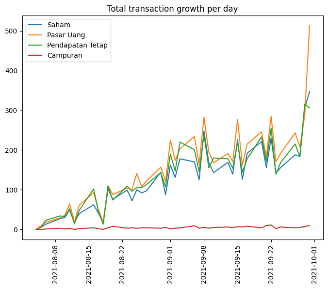

```python
trans_count = data2[['count_saham', 'count_uang', 'count_fixed', 'count_mixed', 'trans_date']].groupby('trans_date').sum()
t_series = trans_count.index.to_pydatetime()

fig, ax = plt.subplots(figsize=(8, 6))

ax.plot(t_series, trans_count)
plt.title('Total transaction growth per day')
plt.legend(['Saham', 'Pasar Uang', 'Pendapatan Tetap', 'Campuran'])
plt.setp(ax.xaxis.get_ticklabels(), rotation=90)
plt.savefig('transaction_growth.jpg')
plt.show()
```

From the number of transactions chart, the higher type of transaction is Pasar Uang (Money Market) follow by Pendapatan Tetap (fixed income) and Saham (stocks) respectively. As we can see from the dataset, the AUM and invested amount is updated daily, meanwhile transactions is filled when the users make any buy or sell transactions and it will fill with 0 if no transactions has been made. Furthermore, we will be separating buy and sell transactions into new columns, to avoid biased data when summarise the transactions.

```python
trans_buysell = ['Saham_transaction_amount','Pasar_Uang_transaction_amount', 'Pendapatan_Tetap_transaction_amount', 'Campuran_transaction_amount']

for x in trans_buysell:
    mask = data2[x] < 0
    data2[x+'_buy'] = data2[x].mask(mask).abs()
    data2[x+'_sell'] = data2[x].mask(~mask).abs()
```

```python
data2.loc[data2.Saham_transaction_amount !=0.00,:].head()
```

|  | user_id | trans_date | Saham_AUM | Saham_invested_amount | Saham_transaction_amount | Pasar_Uang_AUM | Pasar_Uang_invested_amount | Pasar_Uang_transaction_amount | Pendapatan_Tetap_AUM | Pendapatan_Tetap_invested_amount | ... | count_fixed | count_mixed | Saham_transaction_amount_buy | Saham_transaction_amount_sell | Pasar_Uang_transaction_amount_buy | Pasar_Uang_transaction_amount_sell | Pendapatan_Tetap_transaction_amount_buy | Pendapatan_Tetap_transaction_amount_sell | Campuran_transaction_amount_buy | Campuran_transaction_amount_sell |
| --- | --- | --- | --- | --- | --- | --- | --- | --- | --- | --- | --- | --- | --- | --- | --- | --- | --- | --- | --- | --- | --- |
| 25 | 50961 | 2021-09-01 | 1705566.0 | 1700000.0 | 1000000.0 | 100065.0 | 100000.0 | 0.0 | 200124.0 | 200000.0 | ... | 0 | 0 | 1000000.0 | NaN | 0.0 | NaN | 0.0 | NaN | 0.0 | NaN |
| 46 | 50961 | 2021-09-30 | 2063909.0 | 2000000.0 | 300000.0 | 700603.0 | 700000.0 | 600000.0 | 1398998.0 | 1400000.0 | ... | 1 | 0 | 300000.0 | NaN | 600000.0 | NaN | 1200000.0 | NaN | 0.0 | NaN |
| 102 | 61414 | 2021-08-13 | 0.0 | 0.0 | -10000.0 | 0.0 | 0.0 | 0.0 | 0.0 | 0.0 | ... | 0 | 0 | NaN | 10000.0 | 0.0 | NaN | 0.0 | NaN | 0.0 | NaN |
| 154 | 66145 | 2021-09-29 | 248015.0 | 240000.0 | 140000.0 | 29992.0 | 30000.0 | 0.0 | 129929.0 | 130000.0 | ... | 0 | 0 | 140000.0 | NaN | 0.0 | NaN | 0.0 | NaN | 0.0 | NaN |
| 166 | 67251 | 2021-09-20 | 562777.0 | 570000.0 | 530000.0 | 110065.0 | 110000.0 | 100000.0 | 420268.0 | 420000.0 | ... | 1 | 0 | 530000.0 | NaN | 100000.0 | NaN | 370000.0 | NaN | 0.0 | NaN |

5 rows × 26 columns

Since we split the transactions into buy and sell, we will drop the previous transactions column.

```python
data2.drop(trans_buysell, axis=1, inplace=True)
data2.head()
```

|  | user_id | trans_date | Saham_AUM | Saham_invested_amount | Pasar_Uang_AUM | Pasar_Uang_invested_amount | Pendapatan_Tetap_AUM | Pendapatan_Tetap_invested_amount | Campuran_AUM | Campuran_invested_amount | ... | count_fixed | count_mixed | Saham_transaction_amount_buy | Saham_transaction_amount_sell | Pasar_Uang_transaction_amount_buy | Pasar_Uang_transaction_amount_sell | Pendapatan_Tetap_transaction_amount_buy | Pendapatan_Tetap_transaction_amount_sell | Campuran_transaction_amount_buy | Campuran_transaction_amount_sell |
| --- | --- | --- | --- | --- | --- | --- | --- | --- | --- | --- | --- | --- | --- | --- | --- | --- | --- | --- | --- | --- | --- |
| 0 | 50701 | 2021-08-30 | 0.0 | 0.0 | 0.0 | 0.0 | 0.0 | 0.0 | 10132277.0 | 10000000.0 | ... | 0 | 0 | 0.0 | NaN | 0.0 | NaN | 0.0 | NaN | 0.0 | NaN |
| 1 | 50701 | 2021-08-31 | 0.0 | 0.0 | 0.0 | 0.0 | 0.0 | 0.0 | 10206945.0 | 10000000.0 | ... | 0 | 0 | 0.0 | NaN | 0.0 | NaN | 0.0 | NaN | 0.0 | NaN |
| 2 | 50701 | 2021-09-01 | 0.0 | 0.0 | 0.0 | 0.0 | 0.0 | 0.0 | 9956556.0 | 10000000.0 | ... | 0 | 0 | 0.0 | NaN | 0.0 | NaN | 0.0 | NaN | 0.0 | NaN |
| 3 | 50701 | 2021-09-02 | 0.0 | 0.0 | 0.0 | 0.0 | 0.0 | 0.0 | 9914858.0 | 10000000.0 | ... | 0 | 0 | 0.0 | NaN | 0.0 | NaN | 0.0 | NaN | 0.0 | NaN |
| 4 | 50701 | 2021-09-03 | 0.0 | 0.0 | 0.0 | 0.0 | 0.0 | 0.0 | 10016360.0 | 10000000.0 | ... | 0 | 0 | 0.0 | NaN | 0.0 | NaN | 0.0 | NaN | 0.0 | NaN |

5 rows × 22 columns

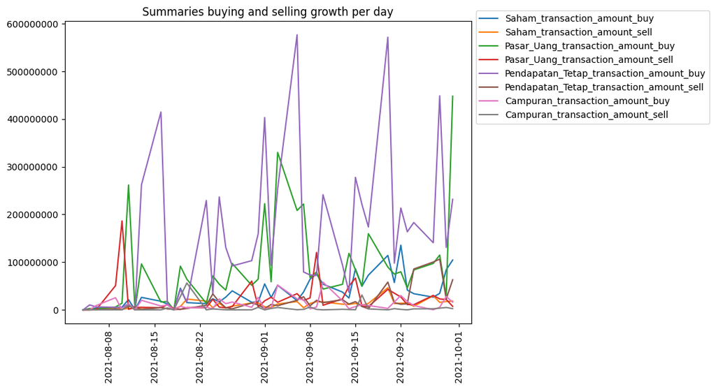

```python
buysell = data2[['Saham_transaction_amount_buy', 'Saham_transaction_amount_sell', 'Pasar_Uang_transaction_amount_buy', 'Pasar_Uang_transaction_amount_sell',
 'Pendapatan_Tetap_transaction_amount_buy', 'Pendapatan_Tetap_transaction_amount_sell','Campuran_transaction_amount_buy', 'Campuran_transaction_amount_sell',
 'trans_date']].groupby('trans_date').sum()
t_series = buysell.index.to_pydatetime()

fig, ax = plt.subplots(figsize=(8, 6))

ax.plot(t_series, buysell)
plt.title('Summaries buying and selling growth per day')
ax.legend(['Saham_transaction_amount_buy', 'Saham_transaction_amount_sell', 'Pasar_Uang_transaction_amount_buy', 'Pasar_Uang_transaction_amount_sell',
 'Pendapatan_Tetap_transaction_amount_buy', 'Pendapatan_Tetap_transaction_amount_sell','Campuran_transaction_amount_buy', 'Campuran_transaction_amount_sell'],
 bbox_to_anchor=(1,1.05))
plt.setp(ax.xaxis.get_ticklabels(), rotation=90)
plt.ticklabel_format(style='plain', axis='y')

plt.show()
```

```python
pd.options.display.float_format = '{:.2f}'.format
```

## important notes

if use .sum() it won't update if we gonna put into a new column with the current dataset, because it will create index based on the groupby. so we have to use transform('sum') instead. sum() only work if we create new variable

```python
invested_col = ['user_id', 'trans_date', 'Saham_AUM', 'Saham_invested_amount', 'Pasar_Uang_AUM', 'Pasar_Uang_invested_amount', 'Pendapatan_Tetap_AUM',
       'Pendapatan_Tetap_invested_amount', 'Campuran_AUM', 'Campuran_invested_amount']
invested_AUM = data2.sort_values(by='trans_date').drop_duplicates(subset=['user_id'], keep='last').reset_index(drop=True)
invested_AUM = invested_AUM[invested_col].copy()
print(f'Total rows: {invested_AUM.shape[0]}, columns: {invested_AUM.shape[1]}\nInvested:')
invested_AUM.head()
```

```
Total rows: 8277, columns: 10
Invested:
```

|  | user_id | trans_date | Saham_AUM | Saham_invested_amount | Pasar_Uang_AUM | Pasar_Uang_invested_amount | Pendapatan_Tetap_AUM | Pendapatan_Tetap_invested_amount | Campuran_AUM | Campuran_invested_amount |
| --- | --- | --- | --- | --- | --- | --- | --- | --- | --- | --- |
| 0 | 3786300 | 2021-09-30 | 0.00 | 0.00 | 0.00 | 0.00 | 0.00 | 0.00 | 0.00 | 0.00 |
| 1 | 3760891 | 2021-09-30 | 258975.00 | 249864.00 | 0.00 | 0.00 | 553302.00 | 550000.00 | 0.00 | 0.00 |
| 2 | 4096532 | 2021-09-30 | 13803192.00 | 13352136.00 | 2390277.00 | 2387932.00 | 8134491.00 | 8149154.00 | 0.00 | 0.00 |
| 3 | 2836295 | 2021-09-30 | 0.00 | 0.00 | 0.00 | 0.00 | 0.00 | 0.00 | 0.00 | 0.00 |
| 4 | 2839273 | 2021-09-30 | 0.00 | 0.00 | 10028.00 | 10000.00 | 0.00 | 0.00 | 0.00 | 0.00 |

trans_buysell = ['Saham_transaction_amount','Pasar_Uang_transaction_amount', 'Pendapatan_Tetap_transaction_amount', 'Campuran_transaction_amount']

# groupRes = data2[['Saham_transaction_amount','Pasar_Uang_transaction_amount', 'Pendapatan_Tetap_transaction_amount', 'Campuran_transaction_amount', 'user_id']].groupby('user_id')

'''groupRes = data2[trans_buysell].groupby('user_id')

# lambda function

for x in trans_buysell: data2[x+'_'] = groupRes[x].agg([(x+'_buy', plus), (x+'_sell', minus)])

for x in counts_: data2[x+'_sum'] = data2[[x, 'user_id']].groupby('user_id').transform('sum')

groupRes = groupRes[groupRes['Saham_transaction_amount']>=0].join(groupRes[groupRes['Saham_transaction_amount']<0], lsuffix="_buy", rsuffix="_sell")'''

```python
data2.columns
```

```
Index(['user_id', 'trans_date', 'Saham_AUM', 'Saham_invested_amount',
       'Pasar_Uang_AUM', 'Pasar_Uang_invested_amount', 'Pendapatan_Tetap_AUM',
       'Pendapatan_Tetap_invested_amount', 'Campuran_AUM',
       'Campuran_invested_amount', 'count_saham', 'count_uang', 'count_fixed',
       'count_mixed', 'Saham_transaction_amount_buy',
       'Saham_transaction_amount_sell', 'Pasar_Uang_transaction_amount_buy',
       'Pasar_Uang_transaction_amount_sell',
       'Pendapatan_Tetap_transaction_amount_buy',
       'Pendapatan_Tetap_transaction_amount_sell',
       'Campuran_transaction_amount_buy', 'Campuran_transaction_amount_sell'],
      dtype='object')
```

```python
sum_trans_total = data2.groupby('user_id')[['Saham_transaction_amount_buy',
       'Saham_transaction_amount_sell', 'Pasar_Uang_transaction_amount_buy',
       'Pasar_Uang_transaction_amount_sell',
       'Pendapatan_Tetap_transaction_amount_buy',
       'Pendapatan_Tetap_transaction_amount_sell',
       'Campuran_transaction_amount_buy', 'Campuran_transaction_amount_sell',
'count_saham', 'count_uang', 'count_fixed', 'count_mixed']].sum()
print(f'Total rows:{sum_trans_total.shape[0]}, columns: {sum_trans_total.shape[1]}\nTransactions:')
sum_trans_total.head()
```

```
Total rows:8277, columns: 12
Transactions:
```

| user_id | Saham_transaction_amount_buy | Saham_transaction_amount_sell | Pasar_Uang_transaction_amount_buy | Pasar_Uang_transaction_amount_sell | Pendapatan_Tetap_transaction_amount_buy | Pendapatan_Tetap_transaction_amount_sell | Campuran_transaction_amount_buy | Campuran_transaction_amount_sell | count_saham | count_uang | count_fixed | count_mixed |
| --- | --- | --- | --- | --- | --- | --- | --- | --- | --- | --- | --- | --- |
| 50701 | 0.00 | 0.00 | 0.00 | 0.00 | 0.00 | 0.00 | 0.00 | 0.00 | 0 | 0 | 0 | 0 |
| 50961 | 1300000.00 | 0.00 | 600000.00 | 0.00 | 1200000.00 | 0.00 | 0.00 | 0.00 | 2 | 1 | 1 | 0 |
| 53759 | 0.00 | 0.00 | 0.00 | 0.00 | 0.00 | 0.00 | 0.00 | 0.00 | 0 | 0 | 0 | 0 |
| 54759 | 0.00 | 0.00 | 2000000.00 | 0.00 | 0.00 | 0.00 | 0.00 | 0.00 | 0 | 1 | 0 | 0 |
| 61414 | 0.00 | 10000.00 | 0.00 | 0.00 | 0.00 | 0.00 | 0.00 | 0.00 | 1 | 0 | 0 | 0 |

```python
new_data2 = invested_AUM.merge(sum_trans_total, on='user_id')
print(f'Total rows: {new_data2.shape[0]}, columns:{new_data2.shape[1]}')
del invested_AUM, sum_trans_total
new_data2.head()
```

```
Total rows: 8277, columns:22
```

|  | user_id | trans_date | Saham_AUM | Saham_invested_amount | Pasar_Uang_AUM | Pasar_Uang_invested_amount | Pendapatan_Tetap_AUM | Pendapatan_Tetap_invested_amount | Campuran_AUM | Campuran_invested_amount | ... | Pasar_Uang_transaction_amount_buy | Pasar_Uang_transaction_amount_sell | Pendapatan_Tetap_transaction_amount_buy | Pendapatan_Tetap_transaction_amount_sell | Campuran_transaction_amount_buy | Campuran_transaction_amount_sell | count_saham | count_uang | count_fixed | count_mixed |
| --- | --- | --- | --- | --- | --- | --- | --- | --- | --- | --- | --- | --- | --- | --- | --- | --- | --- | --- | --- | --- | --- |
| 0 | 3786300 | 2021-09-30 | 0.00 | 0.00 | 0.00 | 0.00 | 0.00 | 0.00 | 0.00 | 0.00 | ... | 0.00 | 10000.00 | 0.00 | 0.00 | 0.00 | 0.00 | 1 | 1 | 0 | 0 |
| 1 | 3760891 | 2021-09-30 | 258975.00 | 249864.00 | 0.00 | 0.00 | 553302.00 | 550000.00 | 0.00 | 0.00 | ... | 310000.00 | 410000.00 | 499783.00 | 49783.00 | 0.00 | 0.00 | 5 | 7 | 7 | 0 |
| 2 | 4096532 | 2021-09-30 | 13803192.00 | 13352136.00 | 2390277.00 | 2387932.00 | 8134491.00 | 8149154.00 | 0.00 | 0.00 | ... | 1937932.00 | 0.00 | 6619154.00 | 0.00 | 0.00 | 0.00 | 2 | 1 | 2 | 0 |
| 3 | 2836295 | 2021-09-30 | 0.00 | 0.00 | 0.00 | 0.00 | 0.00 | 0.00 | 0.00 | 0.00 | ... | 0.00 | 100000.00 | 0.00 | 0.00 | 0.00 | 0.00 | 1 | 1 | 0 | 0 |
| 4 | 2839273 | 2021-09-30 | 0.00 | 0.00 | 10028.00 | 10000.00 | 0.00 | 0.00 | 0.00 | 0.00 | ... | 0.00 | 0.00 | 0.00 | 40000.00 | 0.00 | 0.00 | 1 | 0 | 1 | 0 |

5 rows × 22 columns

We have done handled the null value and convert the correct datatype from dataset 2. So, we will continue to investigate the outliers by merging the dataset 2 and outliers dataframe.

# merge outliers with transaction dataset

trans_outliers = user_outliers[['user_id', 'user_age']].merge(new_data2, on='user_id')

# check how many outliers' user making transaction

total_out_transaction = trans_outliers.user_id.nunique()

# calculate the percentage

# summarise total transaction for outliers only

sum_trans_outliers = trans_outliers.groupby('user_id')[['Saham_transaction_amount', 'Pasar_Uang_transaction_amount', 'Pendapatan_Tetap_transaction_amount', 'Campuran_transaction_amount']].sum()

# summarise total transaction the whole user

sum_trans_total.head()

# visual the imbalanced data using charts

fig= plt.figure(figsize=(10,5) ) fig.add_subplot(1,2,1)

# labels = ['Fraud', 'Non-Fraud']

trans_outliers = [trans_comparison.max_outlier, trans_comparison.mean_outlier] trans_total = [trans_comparison.max_total, trans_comparison.mean_total]

trans_comparison.plot(kind='barh')

# cek jika jumlah total user dari dataset1 sama dengan dataset2

total_data1 = data1.user_id.nunique() total_data2 = data2.user_id.nunique()

print(f'Total User Dataset 1: {total_data1}') print(f'Total User Dataset 2: {total_data2}') print(f'Selisih :{total_data2-total_data1}')

# take out from analysis

idx= ['saham', 'campuran', 'pasar uang', 'pendapatan tetap'] sum_outliers = [trans_outliers.Saham_transaction_amount.max(), trans_outliers.Campuran_transaction_amount.max(), trans_outliers.Pasar_Uang_transaction_amount.max(), trans_outliers.Pendapatan_Tetap_transaction_amount.max()] sum_full = [new_data2.Saham_transaction_amount.max(), new_data2.Campuran_transaction_amount.max(), new_data2.Pasar_Uang_transaction_amount.max(), new_data2.Pendapatan_Tetap_transaction_amount.max()]

```python
print(f'Total rows: {data3.shape[0]}, columns:{data3.shape[1]}')
print(f'Total User: {data3.user_id.nunique()}')
data3.info()
```

```
Total rows: 14714, columns:3
Total User: 8484
<class 'pandas.core.frame.DataFrame'>
RangeIndex: 14714 entries, 0 to 14713
Data columns (total 3 columns):
 #   Column              Non-Null Count  Dtype
---  ------              --------------  -----
 0   user_id             8484 non-null   float64
 1   flag_order_bond     8484 non-null   float64
 2   bond_units_ordered  8484 non-null   float64
dtypes: float64(3)
memory usage: 345.0 KB
```

Since our problem statement is to find the prediction whether the user will order bonds based on their behaviour. We want to see the percentage that users order bonds from the dataset 3 to see the comparison between each class.

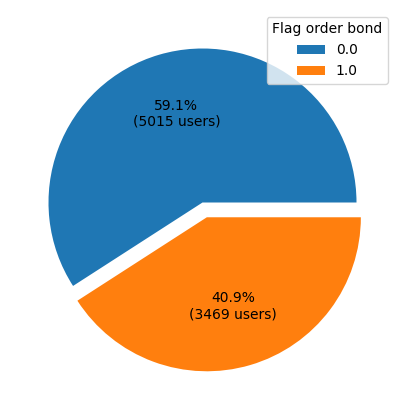

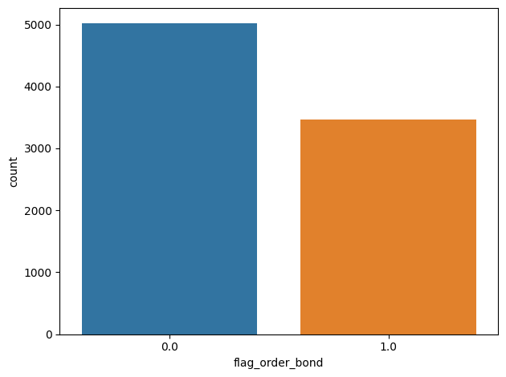

```python
bond_order = data3[['user_id', 'flag_order_bond']].groupby('flag_order_bond').count()
fig, ax = plt.subplots(figsize=(5, 5), subplot_kw=dict(aspect="equal"))
wedges, texts, autotexts = ax.pie(bond_order.user_id, autopct=lambda pct: func(pct, bond_order.user_id),
                                  textprops=dict(color="black"), explode=(0,0.1))
ax.legend(wedges, bond_order.index, title='Flag order bond', loc='upper right')
plt.show()

bond_chart=sns.countplot(x=data3["flag_order_bond"])
plt.tight_layout()
plt.show()
```

```python
data2_3 = data3.merge(new_data2, how='left')
print(f'Total combined rows: {data2_3.shape[0]}, columns:{data2_3.shape[1]}')
data2_3.head()
```

```
Total combined rows: 14714, columns:24
```

|  | user_id | flag_order_bond | bond_units_ordered | trans_date | Saham_AUM | Saham_invested_amount | Pasar_Uang_AUM | Pasar_Uang_invested_amount | Pendapatan_Tetap_AUM | Pendapatan_Tetap_invested_amount | ... | Pasar_Uang_transaction_amount_buy | Pasar_Uang_transaction_amount_sell | Pendapatan_Tetap_transaction_amount_buy | Pendapatan_Tetap_transaction_amount_sell | Campuran_transaction_amount_buy | Campuran_transaction_amount_sell | count_saham | count_uang | count_fixed | count_mixed |
| --- | --- | --- | --- | --- | --- | --- | --- | --- | --- | --- | --- | --- | --- | --- | --- | --- | --- | --- | --- | --- | --- |
| 0 | 50701.00 | 1.00 | 34.00 | 2021-09-30 | 0.00 | 0.00 | 0.00 | 0.00 | 0.00 | 0.00 | ... | 0.00 | 0.00 | 0.00 | 0.00 | 0.00 | 0.00 | 0.00 | 0.00 | 0.00 | 0.00 |
| 1 | 50961.00 | 1.00 | 99.00 | 2021-09-30 | 2063909.00 | 2000000.00 | 700603.00 | 700000.00 | 1398998.00 | 1400000.00 | ... | 600000.00 | 0.00 | 1200000.00 | 0.00 | 0.00 | 0.00 | 2.00 | 1.00 | 1.00 | 0.00 |
| 2 | 51883.00 | 0.00 | 0.00 | NaT | NaN | NaN | NaN | NaN | NaN | NaN | ... | NaN | NaN | NaN | NaN | NaN | NaN | NaN | NaN | NaN | NaN |
| 3 | 53759.00 | 0.00 | 0.00 | 2021-09-30 | 73179.00 | 70000.00 | 10027.00 | 10000.00 | 20109.00 | 20000.00 | ... | 0.00 | 0.00 | 0.00 | 0.00 | 0.00 | 0.00 | 0.00 | 0.00 | 0.00 | 0.00 |
| 4 | 54759.00 | 1.00 | 92.00 | 2021-09-30 | 0.00 | 0.00 | 12049049.00 | 12000000.00 | 0.00 | 0.00 | ... | 2000000.00 | 0.00 | 0.00 | 0.00 | 0.00 | 0.00 | 0.00 | 1.00 | 0.00 | 0.00 |

5 rows × 24 columns

```python
print(f'Difference total users:{data2_3.user_id.nunique()-transaction_users}')
data2_3.isnull().sum()
```

```
Difference total users:207
```

```
user_id                                     6230
flag_order_bond                             6230
bond_units_ordered                          6230
trans_date                                  6437
Saham_AUM                                   6437
Saham_invested_amount                       6437
Pasar_Uang_AUM                              6437
Pasar_Uang_invested_amount                  6437
Pendapatan_Tetap_AUM                        6437
Pendapatan_Tetap_invested_amount            6437
Campuran_AUM                                6437
Campuran_invested_amount                    6437
Saham_transaction_amount_buy                6437
Saham_transaction_amount_sell               6437
Pasar_Uang_transaction_amount_buy           6437
Pasar_Uang_transaction_amount_sell          6437
Pendapatan_Tetap_transaction_amount_buy     6437
Pendapatan_Tetap_transaction_amount_sell    6437
Campuran_transaction_amount_buy             6437
Campuran_transaction_amount_sell            6437
count_saham                                 6437
count_uang                                  6437
count_fixed                                 6437
count_mixed                                 6437
dtype: int64
```

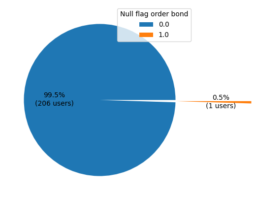

```python
v = data2_3[data2_3.isnull().any(axis=1)]

v_null = v[['user_id', 'flag_order_bond']].groupby('flag_order_bond').count()
fig, ax = plt.subplots(figsize=(5, 5), subplot_kw=dict(aspect="equal"))

wedges, texts, autotexts = ax.pie(v_null.user_id, autopct=lambda pct: func(pct, v_null.user_id),
                                  textprops=dict(color="black"), explode=(0,1))
ax.legend(wedges, v_null.index, title='Null flag order bond', loc='upper right')
plt.show()
```

```python
df1 = new_data2.merge(data1, how='inner', on='user_id')
print(df1.shape)
df1.head()
```

```
(8277, 30)
```

|  | user_id | trans_date | Saham_AUM | Saham_invested_amount | Pasar_Uang_AUM | Pasar_Uang_invested_amount | Pendapatan_Tetap_AUM | Pendapatan_Tetap_invested_amount | Campuran_AUM | Campuran_invested_amount | ... | count_fixed | count_mixed | registration_import_datetime | user_gender | user_age | user_occupation | user_income_range | referral_code_used | user_income_source | registration_month |
| --- | --- | --- | --- | --- | --- | --- | --- | --- | --- | --- | --- | --- | --- | --- | --- | --- | --- | --- | --- | --- | --- |
| 0 | 3786300 | 2021-09-30 | 0.00 | 0.00 | 0.00 | 0.00 | 0.00 | 0.00 | 0.00 | 0.00 | ... | 0 | 0 | 2021-08-07 | Male | 27 | Pelajar | < 10 Juta | used referral | Keuntungan Bisnis | 2021-08-31 |
| 1 | 3760891 | 2021-09-30 | 258975.00 | 249864.00 | 0.00 | 0.00 | 553302.00 | 550000.00 | 0.00 | 0.00 | ... | 7 | 0 | 2021-08-06 | Male | 45 | Swasta | Rp 10 Juta - 50 Juta | None | Gaji | 2021-08-31 |
| 2 | 4096532 | 2021-09-30 | 13803192.00 | 13352136.00 | 2390277.00 | 2387932.00 | 8134491.00 | 8149154.00 | 0.00 | 0.00 | ... | 2 | 0 | 2021-09-19 | Male | 27 | Others | > Rp 100 Juta - 500 Juta | used referral | Gaji | 2021-09-30 |
| 3 | 2836295 | 2021-09-30 | 0.00 | 0.00 | 0.00 | 0.00 | 0.00 | 0.00 | 0.00 | 0.00 | ... | 0 | 0 | 2021-08-15 | Male | 31 | Swasta | < 10 Juta | None | Gaji | 2021-08-31 |
| 4 | 2839273 | 2021-09-30 | 0.00 | 0.00 | 10028.00 | 10000.00 | 0.00 | 0.00 | 0.00 | 0.00 | ... | 1 | 0 | 2021-09-02 | Male | 33 | Swasta | Rp 10 Juta - 50 Juta | None | Lainnya | 2021-09-30 |

5 rows × 30 columns

```python
full_data = df1.merge(data3, how='inner', on='user_id')
print(f'Total full rows: {full_data.shape[0]}, columns:{full_data.shape[1]}')
full_data.head()
```

```
Total full rows: 8277, columns:32
```

|  | user_id | trans_date | Saham_AUM | Saham_invested_amount | Pasar_Uang_AUM | Pasar_Uang_invested_amount | Pendapatan_Tetap_AUM | Pendapatan_Tetap_invested_amount | Campuran_AUM | Campuran_invested_amount | ... | registration_import_datetime | user_gender | user_age | user_occupation | user_income_range | referral_code_used | user_income_source | registration_month | flag_order_bond | bond_units_ordered |
| --- | --- | --- | --- | --- | --- | --- | --- | --- | --- | --- | --- | --- | --- | --- | --- | --- | --- | --- | --- | --- | --- |
| 0 | 3786300 | 2021-09-30 | 0.00 | 0.00 | 0.00 | 0.00 | 0.00 | 0.00 | 0.00 | 0.00 | ... | 2021-08-07 | Male | 27 | Pelajar | < 10 Juta | used referral | Keuntungan Bisnis | 2021-08-31 | 0.00 | 0.00 |
| 1 | 3760891 | 2021-09-30 | 258975.00 | 249864.00 | 0.00 | 0.00 | 553302.00 | 550000.00 | 0.00 | 0.00 | ... | 2021-08-06 | Male | 45 | Swasta | Rp 10 Juta - 50 Juta | None | Gaji | 2021-08-31 | 1.00 | 65.00 |
| 2 | 4096532 | 2021-09-30 | 13803192.00 | 13352136.00 | 2390277.00 | 2387932.00 | 8134491.00 | 8149154.00 | 0.00 | 0.00 | ... | 2021-09-19 | Male | 27 | Others | > Rp 100 Juta - 500 Juta | used referral | Gaji | 2021-09-30 | 1.00 | 91.00 |
| 3 | 2836295 | 2021-09-30 | 0.00 | 0.00 | 0.00 | 0.00 | 0.00 | 0.00 | 0.00 | 0.00 | ... | 2021-08-15 | Male | 31 | Swasta | < 10 Juta | None | Gaji | 2021-08-31 | 0.00 | 0.00 |
| 4 | 2839273 | 2021-09-30 | 0.00 | 0.00 | 10028.00 | 10000.00 | 0.00 | 0.00 | 0.00 | 0.00 | ... | 2021-09-02 | Male | 33 | Swasta | Rp 10 Juta - 50 Juta | None | Lainnya | 2021-09-30 | 1.00 | 42.00 |

5 rows × 32 columns

```python
print('Null Values:')
full_data.isnull().sum()
```

```
Null Values:
```

```
user_id                                     0
trans_date                                  0
Saham_AUM                                   0
Saham_invested_amount                       0
Pasar_Uang_AUM                              0
Pasar_Uang_invested_amount                  0
Pendapatan_Tetap_AUM                        0
Pendapatan_Tetap_invested_amount            0
Campuran_AUM                                0
Campuran_invested_amount                    0
Saham_transaction_amount_buy                0
Saham_transaction_amount_sell               0
Pasar_Uang_transaction_amount_buy           0
Pasar_Uang_transaction_amount_sell          0
Pendapatan_Tetap_transaction_amount_buy     0
Pendapatan_Tetap_transaction_amount_sell    0
Campuran_transaction_amount_buy             0
Campuran_transaction_amount_sell            0
count_saham                                 0
count_uang                                  0
count_fixed                                 0
count_mixed                                 0
registration_import_datetime                0
user_gender                                 0
user_age                                    0
user_occupation                             0
user_income_range                           0
referral_code_used                          0
user_income_source                          0
registration_month                          0
flag_order_bond                             0
bond_units_ordered                          0
dtype: int64
```

## Full Dataset exploration

```python
#grouping the customer age as a ranges and update to age coloumn
bins = [17, 20, 30, 40, 50, 60, 70, 80, 100]
labels = ['17-19','20-29','30-39', '40-49', '50-59', '60-69', '70-79', '80+']
full_data['age_group'] = pd.cut(full_data['user_age'], bins, labels = labels,include_lowest = True)
full_data.drop(['user_age'], axis=1, inplace=True)
full_data.head()
```

|  | user_id | trans_date | Saham_AUM | Saham_invested_amount | Pasar_Uang_AUM | Pasar_Uang_invested_amount | Pendapatan_Tetap_AUM | Pendapatan_Tetap_invested_amount | Campuran_AUM | Campuran_invested_amount | ... | registration_import_datetime | user_gender | user_occupation | user_income_range | referral_code_used | user_income_source | registration_month | flag_order_bond | bond_units_ordered | age_group |
| --- | --- | --- | --- | --- | --- | --- | --- | --- | --- | --- | --- | --- | --- | --- | --- | --- | --- | --- | --- | --- | --- |
| 0 | 3786300 | 2021-09-30 | 0.00 | 0.00 | 0.00 | 0.00 | 0.00 | 0.00 | 0.00 | 0.00 | ... | 2021-08-07 | Male | Pelajar | < 10 Juta | used referral | Keuntungan Bisnis | 2021-08-31 | 0.00 | 0.00 | 20-29 |
| 1 | 3760891 | 2021-09-30 | 258975.00 | 249864.00 | 0.00 | 0.00 | 553302.00 | 550000.00 | 0.00 | 0.00 | ... | 2021-08-06 | Male | Swasta | Rp 10 Juta - 50 Juta | None | Gaji | 2021-08-31 | 1.00 | 65.00 | 40-49 |
| 2 | 4096532 | 2021-09-30 | 13803192.00 | 13352136.00 | 2390277.00 | 2387932.00 | 8134491.00 | 8149154.00 | 0.00 | 0.00 | ... | 2021-09-19 | Male | Others | > Rp 100 Juta - 500 Juta | used referral | Gaji | 2021-09-30 | 1.00 | 91.00 | 20-29 |
| 3 | 2836295 | 2021-09-30 | 0.00 | 0.00 | 0.00 | 0.00 | 0.00 | 0.00 | 0.00 | 0.00 | ... | 2021-08-15 | Male | Swasta | < 10 Juta | None | Gaji | 2021-08-31 | 0.00 | 0.00 | 30-39 |
| 4 | 2839273 | 2021-09-30 | 0.00 | 0.00 | 10028.00 | 10000.00 | 0.00 | 0.00 | 0.00 | 0.00 | ... | 2021-09-02 | Male | Swasta | Rp 10 Juta - 50 Juta | None | Lainnya | 2021-09-30 | 1.00 | 42.00 | 30-39 |

5 rows × 32 columns

```python
full_data.age_group.unique()
```

```
['20-29', '40-49', '30-39', '50-59', '17-19', '60-69', '70-79', '80+']
Categories (8, object): ['17-19' < '20-29' < '30-39' < '40-49' < '50-59' < '60-69' < '70-79' < '80+']
```

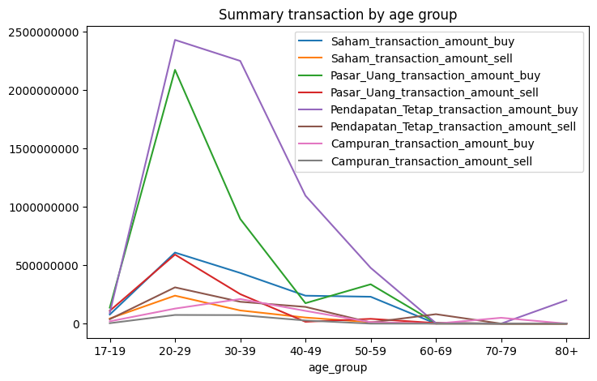

```python
trans_group = full_data[['age_group', 'Saham_transaction_amount_buy',
       'Saham_transaction_amount_sell', 'Pasar_Uang_transaction_amount_buy',
       'Pasar_Uang_transaction_amount_sell',
       'Pendapatan_Tetap_transaction_amount_buy',
       'Pendapatan_Tetap_transaction_amount_sell',
       'Campuran_transaction_amount_buy', 'Campuran_transaction_amount_sell']].groupby('age_group').sum()

trans_group.plot(title='Summary transaction by age group', figsize=(8,5))
plt.ticklabel_format(axis='y', style='plain')
plt.show()
```